Note

Click here to download the full example code or to run this example in your browser via Binder

# Bisecting K-Means and Regular K-Means Performance Comparison

This example shows differences between Regular K-Means algorithm and Bisecting K-Means.

While K-Means clusterings are different when with increasing n_clusters, Bisecting K-Means clustering build on top of the previous ones.

This difference can visually be observed.

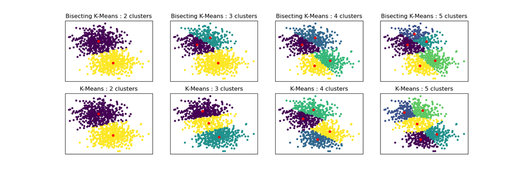

```
import matplotlib.pyplot as plt

from sklearn.datasets import make_blobs
from sklearn.cluster import BisectingKMeans, KMeans


print(__doc__)


# Generate sample data
n_samples = 1000
random_state = 0

X, _ = make_blobs(n_samples=n_samples, centers=2, random_state=random_state)

# Number of cluster centers for KMeans and BisectingKMeans
n_clusters_list = [2, 3, 4, 5]

# Algorithms to compare
clustering_algorithms = {
    "Bisecting K-Means": BisectingKMeans,
    "K-Means": KMeans,
}

# Make subplots for each variant
fig, axs = plt.subplots(
    len(clustering_algorithms), len(n_clusters_list), figsize=(15, 5)
)

axs = axs.T

for i, (algorithm_name, Algorithm) in enumerate(clustering_algorithms.items()):
    for j, n_clusters in enumerate(n_clusters_list):
        algo = Algorithm(n_clusters=n_clusters, random_state=random_state)
        algo.fit(X)
        centers = algo.cluster_centers_

        axs[j, i].scatter(X[:, 0], X[:, 1], s=10, c=algo.labels_)
        axs[j, i].scatter(centers[:, 0], centers[:, 1], c="r", s=20)

        axs[j, i].set_title(f"{algorithm_name} : {n_clusters} clusters")


# Hide x labels and tick labels for top plots and y ticks for right plots.
for ax in axs.flat:
    ax.label_outer()
    ax.set_xticks([])
    ax.set_yticks([])

plt.show()
```

**Total running time of the script:** ( 0 minutes 0.344 seconds)

[figure not shown]

[`Download Python source code: plot_bisect_kmeans.py`](https://scikit-learn.org/1.1/_downloads/73962cec5f14b10630f1a505fe761ab7/plot_bisect_kmeans.py)

[`Download Jupyter notebook: plot_bisect_kmeans.ipynb`](https://scikit-learn.org/1.1/_downloads/13db5212719118ea59532c291af3a8f9/plot_bisect_kmeans.ipynb)

© 2007–2022 The scikit-learn developers  
Licensed under the 3-clause BSD License.  
https://scikit-learn.org/1.1/auto_examples/cluster/plot_bisect_kmeans.html